# Final Project Details

Keith Barnatchez

4/13/2020

## Final Project Implementation Details

This file provides details on the implementation of my analysis of the TICS data in my final project.

## Data loading/cleaning

The raw data is in wide format – there are separate variables for TICS scores over different rounds of interviews. I find it to be more convenient to work with the data in long format, where there are multiple observations per person for the TICS and age variables, since this allows me to more easily account for individuals with less than 5 follow-up interviews in my code.

```r
tics_data <- read.csv('tics.data.2019.csv')

# Make a long format of the TICS data
tics_data$start_age <- tics_data$Age01
tics_long <- reshape(tics_data,
        varying = c("TICS01", "Age01", "TICS02", "Age02", "TICS03",
                    "Age03", "TICS04", "Age04", "TICS05", "Age05"),
        v.names = c("Age","TICS"),
        timevar = "time",
        times = c("1","2","3","4","5"),
        direction = "long")

tics_long <- tics_long[order(tics_long$ID,tics_long$time),]

# Varnames are flipped for some reason. Correct this
colnames(tics_long)[length(colnames(tics_long))-1] <- "Age"
colnames(tics_long)[length(colnames(tics_long))-2] <- "TICS"

tics_long$delta_age <- tics_long$Age - tics_long$start_age
head(tics_long)
```

```
##     ID fam.num sex ptype Age.at.Enrollment Age.Last.Contact Deceased      BMI
## 1.1  1       1   0     1                64               78       No 22.96386
## 1.2  1       1   0     1                64               78       No 22.96386
## 1.3  1       1   0     1                64               78       No 22.96386
## 1.4  1       1   0     1                64               78       No 22.96386
## 1.5  1       1   0     1                64               78       No 22.96386
## 2.1  2       1   0     1                70               84       No       NA
##     SH.Ever.Smoked. MC.Aspirin MC.Stroke MC.Diabetes.Mellitus MC.HTN
## 1.1              No        Yes        No                   No    Yes
## 1.2              No        Yes        No                   No    Yes
## 1.3              No        Yes        No                   No    Yes
## 1.4              No        Yes        No                   No    Yes
## 1.5              No        Yes        No                   No    Yes
## 2.1              No         No        No                   No    Yes
##     MC.Coronary.Artery.Disease MC.Cancer MC.Heart.Attack Years.of.Education
## 1.1                         No       Yes              No                 16
## 1.2                         No       Yes              No                 16
## 1.3                         No       Yes              No                 16
## 1.4                         No       Yes              No                 16
## 1.5                         No       Yes              No                 16
## 2.1                         No        No              No                 19
##     start_age time TICS Age id delta_age
## 1.1        70    1   12  70  1         0
## 1.2        70    2   25  72  1         2
## 1.3        70    3   23  74  1         4
## 1.4        70    4   19  76  1         6
## 1.5        70    5   22  78  1         8
## 2.1        76    1   17  76  2         0
```

## Distinguising confounders

```r
diff_indices <- c()
for (i in 3:17) {
  if (class(tics_data[,i])!="factor") {
  temp_model <- "
  model {
    for (i in 1:N) {
      y[i] ~ dnorm(mu[i],tau)
      mu[i] = b0 + b1*centarian[i]
    }

    # Priors
    b0 ~ dnorm(0,0.00001)
    b1 ~ dnorm(0,0.00001)
    tau ~ dgamma(1,1)

  }
  "
  temp_data <- list(N=nrow(tics_data),
                    y=tics_data[,i],
                    centarian=tics_data$ptype)
  } else {
    temp_model <- "
    model {
    for (i in 1:N) {
      y[i] ~ dbinom(p[i],1)
      logit(p[i]) = b0 + b1*centarian[i]
    }

    # Priors
    b0 ~ dnorm(0,0.00001)
    b1 ~ dnorm(0,0.00001)
  }
  "
    temp_data <- list(N=nrow(tics_data),
                      y=as.numeric(tics_data[,i]=="Yes"),
                      centarian=tics_data$ptype)
  }



temp_model <- jags.model(textConnection(temp_model),data=temp_data)
temp <- update(temp_model,n.iter = 1000)
temp_results <- coda.samples(temp_model,'b1',n.iter = 5000)

# Flag the exceptions
if (!(0 >= summary(temp_results)[[2]][1] & 0 <= summary(temp_results)[[2]][5])) {
  diff_indices <- c(diff_indices,i)
}
}
```

We can look at which variables are found to significantly differ between the two groups:

```r
colnames(tics_data)[diff_indices]
```

```
##  [1] "sex"                        "ptype"
##  [3] "Age.Last.Contact"           "Deceased"
##  [5] "BMI"                        "SH.Ever.Smoked."
##  [7] "MC.Aspirin"                 "MC.Stroke"
##  [9] "MC.Diabetes.Mellitus"       "MC.HTN"
## [11] "MC.Coronary.Artery.Disease"
```

## Main model

```r
tics_long_na <- na.omit(tics_long,cols=Age)
```

Then, I write the model in RJAGS:

```r
main_model_text <- "
model {

  for (i in 1:N) {

    # Impute missing values in BMI
    BMI[i] ~ dnorm(theta[i],nu)
    theta[i] <- a.0 +
                a[1]*sex[i]  +
                a[2]*smoke[i] +
                a[3]*aspirin[i] +
                a[4]*stroke[i] +
                a[5]*cor[i] +
                a[6]*diab[i] +
                a[7]*alive[i]

    # Model for TICS
    tics[i] ~ dnorm(mu[i],tau)
    mu[i] <- alpha[fam[i]] + b_cent*C[i] +
             b_age0*(a0[i]-mean(a0[])) +
             b_age*(delta_age[i]-mean(delta_age[])) +
             b_cent_age*(C[i]*(delta_age[i]-mean(delta_age[]))) +
             g[1]*sex[i] +
             g[2]*(BMI[i]-mean(BMI[])) +
             g[3]*smoke[i] +
             g[4]*aspirin[i] +
             g[5]*stroke[i] +
             g[6]*cor[i] +
             g[7]*diab[i] +
             g[8]*alive[i]
  }

  # Set flat priors for each beta
  b_cent     ~ dnorm(0,0.00001)
  b_age0     ~ dnorm(0,0.00001)
  b_age      ~ dnorm(0,0.00001)
  b_cent_age ~ dnorm(0,0.00001)
  # b0         ~ dnorm(0,0.00001)
  for (i in 1:8) {
    g[i] ~ dnorm(0,0.0001)
  }
  for (i in 1:7) {
    a[i] ~ dnorm(0,0.0001)
  }
  a.0 ~ dnorm(0,0.0001)

  # Set flat priors for random effects
  for (i in 1:max(fam)) {
    alpha[i] ~ dnorm(mu_a,tau_a)
  }

  # Hyper-priors
  tau   ~ dgamma(1,1)
  tau_a ~ dgamma(1,1)
  mu_a  ~ dnorm(0,0.00001)
  nu    ~ dgamma(1,1)
}
"
main_data <- list(N=nrow(tics_long_na),
                  C=tics_long_na$ptype,
                  a0=tics_long_na$start_age,
                  fam=tics_long_na$fam.num,
                  delta_age=tics_long_na$delta_age,
                  tics=tics_long_na$TICS,
                  sex=tics_long_na$sex,
                  BMI=tics_long_na$BMI,
                  smoke=tics_long_na$SH.Ever.Smoked.,
                  aspirin=tics_long_na$MC.Aspirin,
                  stroke=tics_long_na$MC.Stroke,
                  cor=tics_long_na$MC.Coronary.Artery.Disease,
                  diab=tics_long_na$MC.Diabetes.Mellitus,
                  alive=tics_long_na$Deceased,
                  m=as.numeric(is.na(tics_long_na$BMI)==T)
                  )
```

And finally I run 50,000 draws of the MCMC (with 1,000 for burn-in and a thinning interval of 10):

```r
main_model <- jags.model(textConnection(main_model_text),data=main_data)
temp <- update(main_model,n.iter = 1000) # for burn-in

# Check OR output
main_results  <- coda.samples(main_model, c('b_cent','b_age0','b_age','b_cent_age'), n.iter = 50000,thin = 10 )
summary(main_results)
```

```
##
## Iterations = 1010:51000
## Thinning interval = 10
## Number of chains = 1
## Sample size per chain = 5000
##
## 1. Empirical mean and standard deviation for each variable,
##    plus standard error of the mean:
##
##                Mean      SD  Naive SE Time-series SE
## b_age      -0.18765 0.03864 0.0005464      0.0006188
## b_age0     -0.19270 0.01535 0.0002170      0.0002769
## b_cent      0.51082 0.18528 0.0026202      0.0043177
## b_cent_age  0.06446 0.04595 0.0006499      0.0006779
##
## 2. Quantiles for each variable:
##
##                2.5%     25%      50%      75%   97.5%
## b_age      -0.26373 -0.2132 -0.18770 -0.16095 -0.1132
## b_age0     -0.22245 -0.2029 -0.19274 -0.18221 -0.1620
## b_cent      0.15229  0.3830  0.51153  0.63701  0.8787
## b_cent_age -0.02477  0.0333  0.06503  0.09596  0.1544
```

### Diagnostic plots

I check the autocorrelation of my main model MCMC draws:

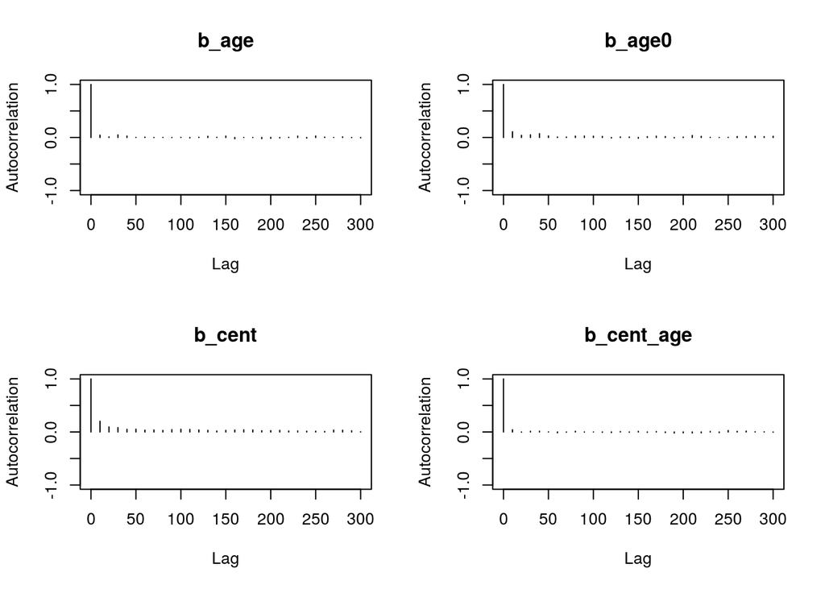

```r
autocorr.plot(main_results)
```

By setting the thinning interval to 10, the autocorrelation is low (this is an issue when not setting a thinning interval). By running the chain long enough (50,000 draws, given 5,000 are kept since the thinning interval is set ti 10) the draws appear stable:

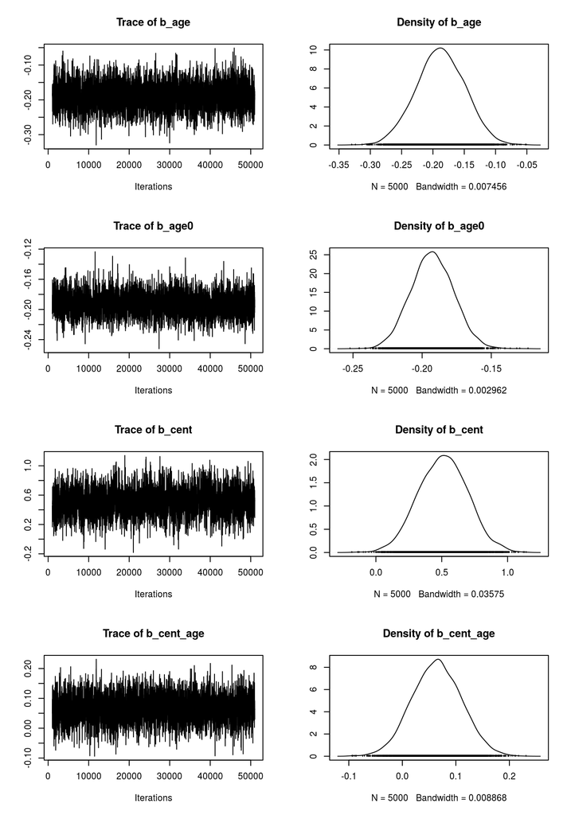

```r
plot(main_results)
```

And testing

```r
geweke.diag(main_results)
```

```
## [[1]]
##
## Fraction in 1st window = 0.1
## Fraction in 2nd window = 0.5
##
##      b_age     b_age0     b_cent b_cent_age
##     0.1625     2.5470    -3.4100    -1.7266
```

## Other details

```r
jags_tex <- function(results,names) {
  # Creates LaTeX table with 50-th pctile and 95% CI,
  # given JAGS summary results and names list for coeffs
  temp_df <- as.data.frame(summary(results)[[2]])

  # 50-th percentile gets its own col
  p50_col <- format(temp_df[,3],digits=3,n.small=1)

  # Make the CI col
  for (i in 1:nrow(temp_df)) {
    ci_col[i] <- paste("(",
                       as.character(format(temp_df[i,1],digits = 3,n.small=1)),
                       ",",
                       as.character(format(temp_df[i,5],digits = 3,n.small=1)),
                       ")",
                       sep = ""
    )
  }

  # Combine and output with xtable
  out_data <- data.frame(p50_col,ci_col)
  colnames(out_data) <- c('Posterior Median','95 percent CI')
  rownames(out_data) <- names

  print(xtable(out_data),
        sanitize.rownames.function = identity,
        booktabs=TRUE)

}
```

### Plots

Since our main questions of interest relate to baseline TICS and TICS rate of change in centenarian offspring vs controls, it’s natural to try to capture these factors in plots. One approach is to plot the distributions of each TICS survey (e.g. TICS1, TICS2, …), but to *split* the data over centenarian offspring and controls, so that there are two plots.

The `ggplot` function gives us everything we need to do this, once we get the data into the right format. I split the data into the two groups, then use the `melt` function to convert the two datasets into a format suitable for `ggplot`:

```r
tics_cent <- data.frame(TICS1=tics_data$TICS01,
                   TICS2=tics_data$TICS02,
                   TICS3=tics_data$TICS03,
                   TICS4=tics_data$TICS04,
                   TICS5=tics_data$TICS05)

cent_idx <- which(tics_data$ptype==1)
nah_idx  <- which(tics_data$ptype==0)

tics_cent <- tics_cent[cent_idx,]
tics_control <- tics_cent[nah_idx,]

tics_cent <- melt(tics_cent)
```

```
## Using  as id variables
```

```r
tics_control <- melt(tics_control)
```

```
## Using  as id variables
```

After formatting the data, we can plot it:

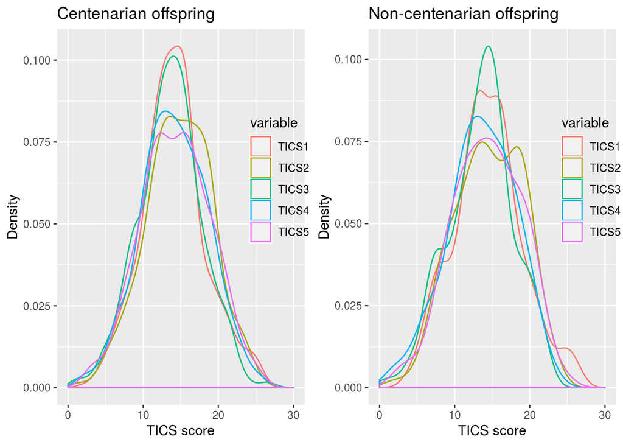

```r
# Plot TICS dists over time, split between centenarians and controls
pcent <- ggplot(tics_cent,aes(x=value, color=variable)) +
         geom_density(alpha=0.15) +
         xlim(0,30) +
         xlab('TICS score') +
         ylab('Density') +
         ggtitle('Centenarian offspring') +
         theme(legend.position = c(0.9,0.6),legend.background = element_blank())


pnah <- ggplot(tics_control,aes(x=value, color=variable)) +
        geom_density(alpha=0.15) +
        xlim(0,30) +
        xlab('TICS score') +
        ylab('Density') +
        ggtitle('Non-centenarian offspring') +
        theme(legend.position = c(0.9,0.6),legend.background = element_blank())


plot_grid(pcent, pnah)
```

And we see it’s a bit unclear whether there are level/rate effects for the centenarian group. That’s what modeling is for!